# chisquare-titanic.R

fabians

2023-11-10

```r
library(DescTools)

# compute chi-square distance and (corrected) contingency coefficient
# arguments:
#   table: a 2D table of absolute frequencies
#   print_stuff: boolean flag -- print intermediate results to console or not
# output:
#  double(3) containing the 3 statistics for the table (rounded, 2 decimals)
chisq_stats <- function(table, print_stuff = TRUE){
  # check args:
  stopifnot(
    inherits(table, "matrix"),
    !any(is.na(table)),
    length(dim(table)) == 2
  )

  sample_size <- sum(table)   #n
  row_freqs <- rowSums(table) #vector of h_i., i = 1,...,k
  col_freqs <- colSums(table) #vector of h_.j, j = 1,...,m
  expected_freqs <- outer(row_freqs, col_freqs) /  sample_size  #~h_ij

  chisq_dist <-
    {(table - expected_freqs)^2 / expected_freqs} |>  # (h_ij - ~h_ij)^2/~h_ij
    sum()
  contingency_coef <- sqrt(chisq_dist / (chisq_dist + sample_size)) # K
  correction_factor <-
    {(min(nrow(table), ncol(table)) - 1) / min(nrow(table), ncol(table))} |>
    sqrt()  # sqrt((min(k, m) - 1)/min(k, m))
  corrected_contingency_coef <- contingency_coef / correction_factor #K*

  if (print_stuff) {
    cat("\n    h_i.:\n")
    print(row_freqs)
    cat("\n    h_.j:\n")
    print(col_freqs)
    cat("\n   h_ij:\n")
    print(table)
    cat("\n   expected ~h_ij under independence:\n")
    print(round(expected_freqs, 2))
    cat("\n")
  }

  c("chisq" = round(chisq_dist, 2),
    "K"     = round(contingency_coef, 2),
    "K*"    = round(corrected_contingency_coef, 2))
}

# compute odds ratio
# arguments:
#   table: a 2x2 table of absolute frequencies
# output: double(1) containing odds ratio
odds_ratio <- function(table) {
  stopifnot(all.equal(dim(table), c(2, 2)))

  # (h_11 * h_22) / (h_21 * h_12)
  (table[1,1] * table[2,2])/(table[2,1] * table[1,2])
}
```

## Example: Sex and Class and Survival on the `Titanic`

Titanic data:

```r
str(Titanic)
```

```
##  'table' num [1:4, 1:2, 1:2, 1:2] 0 0 35 0 0 0 17 0 118 154 ...
##  - attr(*, "dimnames")=List of 4
##   ..$ Class   : chr [1:4] "1st" "2nd" "3rd" "Crew"
##   ..$ Sex     : chr [1:2] "Male" "Female"
##   ..$ Age     : chr [1:2] "Child" "Adult"
##   ..$ Survived: chr [1:2] "No" "Yes"
```

marginal freq.s: survival ~ class

```r
surv_class <- apply(Titanic, MAR = c(4, 1), FUN = sum)
chisq_stats(surv_class)
```

```
##
##     h_i.:
##   No  Yes
## 1490  711
##
##     h_.j:
##  1st  2nd  3rd Crew
##  325  285  706  885
##
##    h_ij:
##         Class
## Survived 1st 2nd 3rd Crew
##      No  122 167 528  673
##      Yes 203 118 178  212
##
##    expected ~h_ij under independence:
##        1st    2nd    3rd   Crew
## No  220.01 192.94 477.94 599.11
## Yes 104.99  92.06 228.06 285.89
```

```
##  chisq      K     K*
## 190.40   0.28   0.40
```

verify that we implemented K* correctly by comparing with a reference implementation from the DescTools package:

```r
DescTools::ContCoef(surv_class, correct = TRUE) # approx 0.4 -- yay!
```

```
## [1] 0.3990465
```

marginal freq.s: survival ~ sex

```r
surv_sex <- apply(Titanic, MAR = c(4, 2), FUN = sum)
chisq_stats(surv_sex)
```

```
##
##     h_i.:
##   No  Yes
## 1490  711
##
##     h_.j:
##   Male Female
##   1731    470
##
##    h_ij:
##         Sex
## Survived Male Female
##      No  1364    126
##      Yes  367    344
##
##    expected ~h_ij under independence:
##        Male Female
## No  1171.83 318.17
## Yes  559.17 151.83
```

```
##  chisq      K     K*
## 456.87   0.41   0.59
```

What if we condition on class, i.e.:  
look at strength of dependency between sex and survival for each class separately.  
First we need the marginal conditional freq.s for survival ~ sex | class:

```r
(surv_sex_class <- apply(Titanic, MAR = c(4, 2, 1), FUN = sum))
```

```
## , , Class = 1st
##
##         Sex
## Survived Male Female
##      No   118      4
##      Yes   62    141
##
## , , Class = 2nd
##
##         Sex
## Survived Male Female
##      No   154     13
##      Yes   25     93
##
## , , Class = 3rd
##
##         Sex
## Survived Male Female
##      No   422    106
##      Yes   88     90
##
## , , Class = Crew
##
##         Sex
## Survived Male Female
##      No   670      3
##      Yes  192     20
```

Visualize this complicated 3D joint distribution:

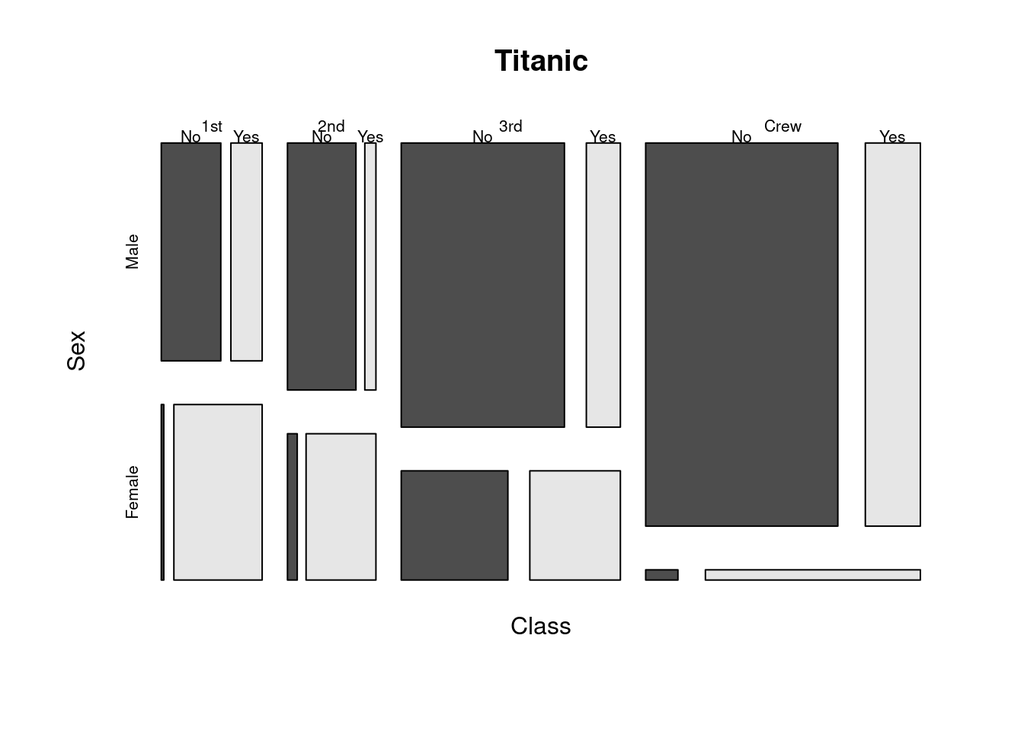

```r
mosaicplot(~ Class + Sex + Survived , data = Titanic, main = "Titanic", color = TRUE)
```

```r
chisq_stats(surv_sex_class[, , "1st"], print = FALSE)
```

```
##  chisq      K     K*
## 135.07   0.54   0.77
```

```r
chisq_stats(surv_sex_class[, , "2nd"], print = FALSE)
```

```
##  chisq      K     K*
## 149.33   0.59   0.83
```

```r
chisq_stats(surv_sex_class[, , "3rd"], print = FALSE)
```

```
## chisq     K    K*
## 61.69  0.28  0.40
```

```r
chisq_stats(surv_sex_class[, , "Crew"], print = FALSE)
```

```
## chisq     K    K*
## 51.45  0.23  0.33
```

$\implies$ sex-survival dependency ordered by decreasing strength as measured by $K^*$:  
2nd > 1st > 3rd > Crew

```r
odds_ratio(surv_sex_class[, , "1st"])
```

```
## [1] 67.08871
```

```r
odds_ratio(surv_sex_class[, , "2nd"])
```

```
## [1] 44.06769
```

```r
odds_ratio(surv_sex_class[, , "3rd"])
```

```
## [1] 4.071612
```

```r
odds_ratio(surv_sex_class[, , "Crew"])
```

```
## [1] 23.26389
```

$\implies$ sex-survival dependency ordered by decreasing strength as measured by OR $\gamma$:  
1st > 2nd > Crew > 3rd (!)

What’s going on, why the discrepancy between OR $\gamma$ and $K^*$?

- $\chi^2$-distance and derived quantities $K$, $K^*$ are affected by the marginal distributions of the sample: The more unbalanced the marginal distributions are, the higher the observed OR needs to be to reach the same value for $K^*$ as for a more balanced sample. In a nutshell, strong deviations from expected counts under independence in subpopulations with small counts might just be due to chance and receive relatively less weight, by construction of the $\chi^2$- statistic.
- OR, in contrast, simply reports the observed relative difference in the odds.